# R for Marketing - Market Basket Analysis

This R code book written by [Rohit Dhankar](https://github.com/RohitDhankar) . GitHub - https://github.com/RohitDhankar

Code and Data > [Rohit Dhankar-GITHUB](https://github.com/RohitDhankar)

The dataset is Copyrighted by -

Brijs T., Swinnen G., Vanhoof K., and Wets G. (1999), The use of association rules for prod- uct assortment decisions: a case study, in: Proceedings of the Fifth International Conference on Knowledge Discovery and Data Mining, San Diego (USA), August 15-18, pp. 254-260. ISBN: 1-58113-143-7.

# R for Marketing - Market Basket Analysis

```r
# Getting the Retail Sales Data -- http://fimi.ua.ac.be/data/retail.pdf
# Data can also be taken from -- http://r-marketing.r-forge.r-project.org
# Also at -- http://www.cis.hut.fi/Opinnot/T-61.5060/2005/t615060-l-2005-09-29-b.pdf
# Set Seed -- ensure reproducible results
set.seed(123)
require(arules) # Mining Association Rules and Frequent Itemsets
#fileURL <- "http://fimi.ua.ac.be/data/retail.dat.gz"
#download.file(fileURL, destfile="retail.data.gz", method="curl")
# Read the data in basket format
transaction_data = read.transactions("retail.data.gz", format = "basket", sep=" ");
write.csv(transaction_data, file = "~/Desktop/R_Own/R_Marketing/Mkt_DATA_Files/retail_raw.csv")   #Save file as .csv file for later use
```

```
Error in as.data.frame.default(x[[i]], optional = TRUE) :
  cannot coerce class "structure("transactions", package = "arules")" to a data.frame
```

# Data Summary

1. Each ROW or Obs of the data is - 1 - Market Basket.
2. Each Market Basket has many different purchase items.
3. There are - 88,162 ROWS.
4. Each ROW mostly has different no. of purchase items.

```r
# Using Function - readLines() from BASE
#
#transaction_data1<- readLines("~/Desktop/R_Own/R_Marketing/Mkt_DATA_Files/retail.dat")
write.csv(transaction_data1, file = "~/Desktop/R_Own/R_Marketing/Mkt_DATA_Files/retail_raw.csv")   #Save file as .csv file for later use
#
```

```r
# Read the HEAD  end of the Data
#
head(transaction_data1)
#
```

[output not shown]

```r
# Read Only the 5th MARKET BASKET and see how many ITEMS in it and WHICH ALL Items ?
#
head(transaction_data1[5])
```

[output not shown]

```r
# Read TAIL end of the Data
#
tail(transaction_data1)
```

[output not shown]

We can now create a DATA STRUCTURE with LABELS for each,  
Market basket. Each Market Basket is also called a - TRANSACTION.

To create LABELS or ROW Names we need a NAMES Vector.  
Lets create a ROW_Labels Vector.

```r
# Code for ROW_Labels vector
#
ROW_Labels <- paste("Market_basket_",1:length(transaction_data1),sep="")
#
typeof(ROW_Labels)
```

```
[1] "character"
```

```r
#
class(ROW_Labels)
```

```
[1] "character"
```

```r
#
ROW_Labels[1:20] # Prints initial 20 LABELS
```

```
 [1] "Market_basket_1"  "Market_basket_2"  "Market_basket_3"  "Market_basket_4"  "Market_basket_5"  "Market_basket_6"  "Market_basket_7"
 [8] "Market_basket_8"  "Market_basket_9"  "Market_basket_10" "Market_basket_11" "Market_basket_12" "Market_basket_13" "Market_basket_14"
[15] "Market_basket_15" "Market_basket_16" "Market_basket_17" "Market_basket_18" "Market_basket_19" "Market_basket_20"
```

```r
#
tail(ROW_Labels) # Market_basket_88162"
```

```
[1] "Market_basket_88157" "Market_basket_88158" "Market_basket_88159" "Market_basket_88160" "Market_basket_88161" "Market_basket_88162"
```

```r
#
str(ROW_Labels)
```

```
 chr [1:88162] "Market_basket_1" "Market_basket_2" "Market_basket_3" "Market_basket_4" "Market_basket_5" "Market_basket_6" ...
```

```r
# As seen above - we have created a CHARACTER Vector with
# ROW_Lables == Market_basket_1 to Market_basket_88162
```

```r
transaction_list <-strsplit(transaction_data1,"")
#
str(transaction_list)
```

```
List of 88162
 $ : chr [1:80] "0" " " "1" " " ...
 $ : chr [1:9] "3" "0" " " "3" ...
 $ : chr [1:9] "3" "3" " " "3" ...
 $ : chr [1:33] "3" "6" " " "3" ...
 $ : chr [1:12] "3" "8" " " "3" ...
 $ : chr [1:39] "3" "8" " " "3" ...
 $ : chr [1:18] "3" "2" " " "4" ...
 $ : chr [1:8] "3" " " "3" "9" ...
 $ : chr [1:18] "6" "3" " " "6" ...
 $ : chr [1:6] "3" "2" " " "6" ...
 $ : chr [1:12] "4" "8" " " "7" ...
 $ : chr [1:24] "3" "9" " " "7" ...
 $ : chr [1:24] "3" "6" " " "3" ...
 $ : chr [1:9] "8" "2" " " "8" ...
```

[output cut: 86 more lines]

```r
#
# We Add the ROW_names Labels
#
names(transaction_list) <- paste("Market_basket_",1:length(transaction_data1),sep="")
#
# Again see the STRUCTURE
#
str(transaction_list) #
```

```
List of 88162
 $ Market_basket_1    : chr [1:80] "0" " " "1" " " ...
 $ Market_basket_2    : chr [1:9] "3" "0" " " "3" ...
 $ Market_basket_3    : chr [1:9] "3" "3" " " "3" ...
 $ Market_basket_4    : chr [1:33] "3" "6" " " "3" ...
 $ Market_basket_5    : chr [1:12] "3" "8" " " "3" ...
 $ Market_basket_6    : chr [1:39] "3" "8" " " "3" ...
 $ Market_basket_7    : chr [1:18] "3" "2" " " "4" ...
 $ Market_basket_8    : chr [1:8] "3" " " "3" "9" ...
 $ Market_basket_9    : chr [1:18] "6" "3" " " "6" ...
 $ Market_basket_10   : chr [1:6] "3" "2" " " "6" ...
 $ Market_basket_11   : chr [1:12] "4" "8" " " "7" ...
 $ Market_basket_12   : chr [1:24] "3" "9" " " "7" ...
 $ Market_basket_13   : chr [1:24] "3" "6" " " "3" ...
 $ Market_basket_14   : chr [1:9] "8" "2" " " "8" ...
```

[output cut: 86 more lines]

```r
#
tail(transaction_list)
```

```
$Market_basket_88157
 [1] "4" "8" " " "2" "0" "1" " " "2" "5" "5" " " "2" "7" "8" " " "4" "0" "7" " " "4" "7" "9" " " "7" "6" "7" " " "8"
[29] "2" "4" " " "9" "8" "6" " " "1" "3" "9" "5" " " "1" "5" "9" "8" " " "2" "0" "2" "2" " " "2" "2" "8" "3" " " "2"
[57] "3" "7" "5" " " "6" "7" "2" "5" " " "1" "3" "3" "3" "4" " " "1" "4" "0" "0" "6" " " "1" "4" "0" "9" "9" " "

$Market_basket_88158
 [1] "3" "9" " " "8" "7" "5" " " "2" "6" "6" "5" " " "2" "9" "6" "2" " " "1" "2" "9" "5" "9" " " "1" "4" "0" "7" "0"
[29] " " "1" "4" "4" "0" "6" " " "1" "5" "5" "1" "8" " " "1" "6" "3" "7" "9" " "

$Market_basket_88159
  [1] "3" "9" " " "4" "1" " " "1" "0" "1" " " "3" "4" "6" " " "3" "9" "3" " " "4" "1" "3" " " "4" "7" "9" " " "5" "2"
 [29] "2" " " "5" "8" "6" " " "6" "3" "5" " " "6" "9" "5" " " "7" "9" "9" " " "1" "4" "6" "6" " " "1" "7" "8" "6" " "
 [57] "1" "9" "9" "4" " " "2" "4" "4" "9" " " "2" "8" "3" "0" " " "3" "0" "3" "5" " " "3" "5" "9" "1" " " "3" "7" "2"
 [85] "2" " " "6" "2" "1" "7" " " "1" "1" "4" "9" "3" " " "1" "2" "1" "2" "9" " " "1" "3" "0" "3" "3" " "

$Market_basket_88160
 [1] "2" "3" "1" "0" " " "4" "2" "6" "7" " "

$Market_basket_88161
 [1] "3" "9" " " "4" "8" " " "2" "5" "2" "8" " "

$Market_basket_88162
 [1] "3" "2" " " "3" "9" " " "2" "0" "5" " " "2" "4" "2" " " "1" "3" "9" "3" " "
```

```r
# market_basket_rules <- apriori(transaction_data, parameter=list(supp=0.001, conf=0.4))
#
# # Create a DF of Rules
# mba_rules_df<- as(market_basket_rules, "data.frame")
# #
# str(mba_rules_df)
#
write.csv(mba_rules_df, file = "~/Desktop/R_Own/R_Marketing/Mkt_DATA_Files/mba_rules_df.csv")
#
```

# DATA VISUALIZATION - arulesVIZ

Visualize Data to make further sense of the Association Rules.

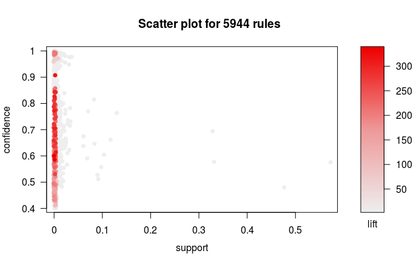

```r
require(arulesViz)
#
plot(market_basket_rules)
```

```r
#
```

```r
#plot(market_basket_rules,interactive=TRUE)
```